# Intro to Urban Analytics

Bon Woo Koo & Subhrajit Guhathakurta

2022-08-20

```r
tidycensus::census_api_key(Sys.getenv("census_api"))
library(tidycensus)
library(sf)
library(tmap)
library(jsonlite)
library(tidyverse)
library(httr)
library(jsonlite)
library(reshape2)
library(here)
library(yelpr)
library(knitr)
```

# Download data from Census 2020

Here we are downloading income, race, and means of transportation to work

```r
FD_tract <- suppressMessages(
  get_acs(geography = "tract", # or "block group", "county", "state" etc.
          state = "GA",
          county = c("Fulton", "Dekalb"),
          variables = c(hhincome = 'B19019_001',
                        race.tot = "B02001_001",
                        race.white = "B02001_002",
                        race.black = "B02001_003",
                        trans.total = "B08006_001",
                        trans.car = "B08006_002",
                        trans.drovealone = "B08006_003",
                        trans.carpooled = "B08006_004", # Notice that I was not interested in 005-007 (2 person/ 4 person carpool etc.)
                        trans.pubtrans = "B08006_008", # Did not want to download any details about the type of public transport (009-0013)
                        trans.bicycle = "B08006_014",
                        trans.walk = "B08006_015",
                        trans.WfH = "B08006_017"
          ),
          year = 2020,
          survey = "acs5", # American Community Survey 5-year estimate
          geometry = TRUE, # returns sf objects
          output = "wide") # wide vs. long
)
```

The data contains several redundant columns that we will not use. So, let’s subset the data to only have the columns we will use

```r
FD_tract <- FD_tract %>%
  select(GEOID,
          hhincome = hhincomeE, # New name = old name
          race.tot = race.totE,
          race.white = race.whiteE,
          race.black = race.blackE,
          trans.total = trans.totalE,
          trans.car = trans.carE,
          trans.drovealone = trans.drovealoneE,
          trans.carpooled = trans.carpooledE,
          trans.pubtrans = trans.pubtransE,
          trans.bicycle = trans.bicycleE,
          trans.walk = trans.walkE,
          trans.WfH = trans.WfHE)

tmap_mode("view")
## tmap mode set to interactive viewing
tm_shape(FD_tract) + tm_borders()
```

[interactive chart not shown]

# Reading Yelp data

**To save time in class, we will use the Yelp data that Bonwoo downloaded for today’s class.**

The Yelp data can be found on **Canvas > Files > yelp_yoga.geojson.** This data is for Fulton and DeKalb County, GA, and contains Yelp data with categories = “yoga”. This data is already cleaned.

To read the data into R, we will use st_read() function in sf package. Notice that in the code below, only the name of the .geojson file is specified. This works only when the file is in the same folder as your .Rmd file. If not, you will need to provide a full path to the file.

```r
# Reading the yelp data
yelp_in <- st_read("yelp_yoga.geojson")
```

# Appending Census data

Here, we will append Yelp data to Census data using st_join(). If you can’t remember how the code works, look at [this slide](https://bonwookoo.github.io/UrbanAnalytics2022/Lab/module_0/w2_d2_Intro_to_R_2.html#37).

```r
# Transforming CRS of census to match that of Yelp data .
# st_join() requires that the CRS are the same for two data.
census_sf <- FD_tract %>% st_sf() %>% st_transform(crs = 4326)
# Spatial join. Notice the order of arguments.
yelp_census <- st_join(yelp_in, census_sf, join = st_intersects)

yelp_census %>% head(3)
```

```
## Simple feature collection with 3 features and 35 fields
## Geometry type: POINT
## Dimension:     XY
## Bounding box:  xmin: -84.34933 ymin: 33.76672 xmax: -84.19098 ymax: 33.79948
## Geodetic CRS:  WGS 84
##                       id                                       alias
## 1 NdD6VWQu4wX1MeUAf1zUQg                    yogashala-stone-mountain
## 2 k5wcy48A57_a_9S_-wRvTw spa-flow-chair-massage-and-wellness-atlanta
## 3 fdK7PXrYtelyWS6NYyI2cg    william-hufschmidt-lmt-e-ryt-500-atlanta
##                                 name
## 1                          Yogashala
## 2  Spa Flow Chair Massage & Wellness
## 3 William Hufschmidt, LMT, E-RYT-500
##                                                              image_url
## 1 https://s3-media4.fl.yelpcdn.com/bphoto/LCQqViW1pEypIJzujsKwGQ/o.jpg
## 2 https://s3-media2.fl.yelpcdn.com/bphoto/gh4aeSfqQ3D4qMyvL7wIgw/o.jpg
## 3 https://s3-media3.fl.yelpcdn.com/bphoto/scC6E32ExL0jhZaZO1vOVg/o.jpg
##   is_closed
## 1     FALSE
## 2     FALSE
## 3     FALSE
##                                                                                                                                                                                                        url
## 1                    https://www.yelp.com/biz/yogashala-stone-mountain?adjust_creative=b4FQCVifxBm7ICooFs7HiA&utm_campaign=yelp_api_v3&utm_medium=api_v3_business_search&utm_source=b4FQCVifxBm7ICooFs7HiA
## 2 https://www.yelp.com/biz/spa-flow-chair-massage-and-wellness-atlanta?adjust_creative=b4FQCVifxBm7ICooFs7HiA&utm_campaign=yelp_api_v3&utm_medium=api_v3_business_search&utm_source=b4FQCVifxBm7ICooFs7HiA
## 3    https://www.yelp.com/biz/william-hufschmidt-lmt-e-ryt-500-atlanta?adjust_creative=b4FQCVifxBm7ICooFs7HiA&utm_campaign=yelp_api_v3&utm_medium=api_v3_business_search&utm_source=b4FQCVifxBm7ICooFs7HiA
##   review_count                      categories rating transactions        phone
## 1            1 Yoga, Meditation Centers, Reiki    5.0              +14702068977
## 2           11  Massage, Massage Therapy, Yoga    4.5              +14045778555
## 3            8 Yoga, Massage Therapy, Trainers    4.5              +14044919176
##    display_phone   distance price location.address1 location.address2
## 1 (470) 206-8977   288.7189  <NA>              <NA>              <NA>
## 2 (404) 577-8555 14697.7309    $$  608 Moreland Ave
## 3 (404) 491-9176 18930.6636  <NA>              <NA>              <NA>
##   location.address3  location.city location.zip_code location.country
## 1                   Stone Mountain             30083               US
## 2                          Atlanta             30307               US
## 3                          Atlanta             31107               US
##   location.state            location.display_address       GEOID hhincome
## 1             GA            Stone Mountain, GA 30083 13089021908    43191
## 2             GA 608 Moreland Ave, Atlanta, GA 30307 13121001600    97623
## 3             GA                   Atlanta, GA 31107 13121001600    97623
##   race.tot race.white race.black trans.total trans.car trans.drovealone
## 1     4829        323       3368        2421      2137             1759
## 2     2322       1886        138        1799      1192             1093
## 3     2322       1886        138        1799      1192             1093
##   trans.carpooled trans.pubtrans trans.bicycle trans.walk trans.WfH
## 1             378             86             0        101        97
## 2              99            159            39         81       318
## 3              99            159            39         81       318
##                     geometry
## 1 POINT (-84.19098 33.79948)
## 2 POINT (-84.34933 33.77094)
## 3 POINT (-84.34921 33.76672)
```

# Start exploring the data – look for summary stats, outliers, and associations

Let’s use skim() function to get a summary of the data.

Notice that the data file has a few missing values - we will not worry about the ones we will not use. We will use household income – so let’s drop the two missing values from hhincome.

```r
library(skimr)
# skim your data
print(skim(yelp_census))
```

```
## ── Data Summary ────────────────────────
##                            Values
## Name                       yelp_census
## Number of rows             161
## Number of columns          36
## _______________________
## Column type frequency:
##   character                20
##   logical                  1
##   numeric                  15
## ________________________
## Group variables            None
##
## ── Variable type: character ────────────────────────────────────────────────────
##    skim_variable            n_missing complete_rate min max empty n_unique
```

[output cut: 79 more lines]

```
## $character
##
## ── Variable type: character ────────────────────────────────────────────────────
##    skim_variable            n_missing complete_r…¹ min max empty n_uni…² white…³
##  1 id                               0       1       22  22     0     161       0
##  2 alias                            0       1       17  58     0     161       0
##  3 name                             0       1        7  49     0     139       0
##  4 image_url                        0       1        0  68     6     156       0
##  5 url                              0       1      174 215     0     161       0
##  6 categories                       0       1        4  47     0      68       0
##  7 transactions                     0       1        0   0   161       1       0
##  8 phone                            0       1        0  12     6     147       0
##  9 display_phone                    0       1        0  14     6     147       0
## 10 price                          155       0.0373   2   2     0       1       0
## 11 location.address1                9       0.944    0  30     7     142       0
## 12 location.address2               35       0.783    0  11    52      59       0
## 13 location.address3               30       0.814    0  26   126       6       0
## 14 location.city                    0       1        6  19     0      21       0
## 15 location.zip_code                0       1        0   5     1      51       0
## 16 location.country                 0       1        2   2     0       1       0
## 17 location.state                   0       1        2   2     0       1       0
## 18 location.display_address         0       1       11  76     0     158       0
## 19 GEOID                            0       1       11  11     0     113       0
## 20 geometry                         0       1       21  38     0     160       0
## # … with abbreviated variable names ¹complete_rate, ²n_unique, ³whitespace
##
## $logical
##
## ── Variable type: logical ──────────────────────────────────────────────────────
##   skim_variable n_missing complete_rate mean count
## 1 is_closed             0             1    0 FAL: 161
##
## $numeric
##
## ── Variable type: numeric ──────────────────────────────────────────────────────
##    skim_vari…¹ n_mis…² compl…³   mean      sd     p0    p25    p50    p75   p100
##  1 review_cou…       0   1     2.29e1 3.42e+1 1   e0     3      9  2.5 e1 1.59e2
##  2 rating            0   1     4.45e0 7.74e-1 2.5 e0     4      5  5   e0 5   e0
##  3 distance          0   1     1.94e3 3.93e+3 5.88e1   847.  1248. 1.79e3 4.30e4
##  4 hhincome          2   0.988 9.93e4 4.14e+4 2.39e4 76117  90694  1.19e5 2.50e5
##  5 race.tot          0   1     3.54e3 1.20e+3 4.65e2  2498   3567  4.47e3 6.89e3
##  6 race.white        0   1     2.24e3 1.14e+3 7   e0  1530   2210  2.98e3 4.93e3
##  7 race.black        0   1     8.10e2 9.25e+2 0        246    556  9.94e2 4.86e3
##  8 trans.total       0   1     1.95e3 6.74e+2 3.79e2  1469   1869  2.43e3 4.11e3
##  9 trans.car         0   1     1.45e3 5.69e+2 2.61e2  1052   1378  1.80e3 3.26e3
## 10 trans.drov…       0   1     1.34e3 5.19e+2 2.36e2   986   1289  1.67e3 2.75e3
## 11 trans.carp…       0   1     1.16e2 1.06e+2 0         55     87  1.45e2 7.38e2
## 12 trans.pubt…       0   1     9.86e1 9.76e+1 0         17     79  1.49e2 4.97e2
## 13 trans.bicy…       0   1     1.98e1 3.78e+1 0          0      0  2.2 e1 2.2 e2
## 14 trans.walk        0   1     7.83e1 1.17e+2 0          0     36  9.3 e1 5.49e2
## 15 trans.WfH         0   1     2.65e2 1.58e+2 1.1 e1   117    276  3.58e2 8.16e2
## # … with 1 more variable: hist <chr>, and abbreviated variable names
## #   ¹skim_variable, ²n_missing, ³complete_rate
## # ℹ Use `colnames()` to see all variable names
```

```r
# Dropping the two missing values
yelp_census_dropnaHH2 <- yelp_census[!is.na(yelp_census$hhincome),]

# Just to check whether the 2 NAs have been dropped
print(skim(yelp_census_dropnaHH2))
```

```
## ── Data Summary ────────────────────────
##                            Values
## Name                       yelp_census_dropnaHH2
## Number of rows             159
## Number of columns          36
## _______________________
## Column type frequency:
##   character                20
##   logical                  1
##   numeric                  15
## ________________________
## Group variables            None
##
## ── Variable type: character ────────────────────────────────────────────────────
##    skim_variable            n_missing complete_rate min max empty n_unique
```

[output cut: 79 more lines]

```
## $character
##
## ── Variable type: character ────────────────────────────────────────────────────
##    skim_variable            n_missing complete_r…¹ min max empty n_uni…² white…³
##  1 id                               0       1       22  22     0     159       0
##  2 alias                            0       1       17  58     0     159       0
##  3 name                             0       1        7  49     0     137       0
##  4 image_url                        0       1        0  68     6     154       0
##  5 url                              0       1      174 215     0     159       0
##  6 categories                       0       1        4  47     0      68       0
##  7 transactions                     0       1        0   0   159       1       0
##  8 phone                            0       1        0  12     5     146       0
##  9 display_phone                    0       1        0  14     5     146       0
## 10 price                          153       0.0377   2   2     0       1       0
## 11 location.address1                8       0.950    0  30     6     142       0
## 12 location.address2               34       0.786    0  11    51      59       0
## 13 location.address3               30       0.811    0  26   124       6       0
## 14 location.city                    0       1        6  19     0      21       0
## 15 location.zip_code                0       1        0   5     1      50       0
## 16 location.country                 0       1        2   2     0       1       0
## 17 location.state                   0       1        2   2     0       1       0
## 18 location.display_address         0       1       11  76     0     157       0
## 19 GEOID                            0       1       11  11     0     111       0
## 20 geometry                         0       1       21  38     0     158       0
## # … with abbreviated variable names ¹complete_rate, ²n_unique, ³whitespace
##
## $logical
##
## ── Variable type: logical ──────────────────────────────────────────────────────
##   skim_variable n_missing complete_rate mean count
## 1 is_closed             0             1    0 FAL: 159
##
## $numeric
##
## ── Variable type: numeric ──────────────────────────────────────────────────────
##    skim_vari…¹ n_mis…² compl…³   mean      sd     p0    p25    p50    p75   p100
##  1 review_cou…       0       1 2.31e1 3.44e+1 1   e0 3   e0     9  2.5 e1 1.59e2
##  2 rating            0       1 4.44e0 7.76e-1 2.5 e0 4   e0     5  5   e0 5   e0
##  3 distance          0       1 1.95e3 3.95e+3 5.88e1 8.41e2  1248. 1.82e3 4.30e4
##  4 hhincome          0       1 9.93e4 4.14e+4 2.39e4 7.61e4 90694  1.19e5 2.50e5
##  5 race.tot          0       1 3.56e3 1.20e+3 4.65e2 2.59e3  3567  4.47e3 6.89e3
##  6 race.white        0       1 2.26e3 1.13e+3 7   e0 1.55e3  2222  2.99e3 4.93e3
##  7 race.black        0       1 8.04e2 9.30e+2 0      2.46e2   542  9.94e2 4.86e3
##  8 trans.total       0       1 1.96e3 6.70e+2 3.79e2 1.48e3  1897  2.43e3 4.11e3
##  9 trans.car         0       1 1.47e3 5.62e+2 2.61e2 1.05e3  1408  1.82e3 3.26e3
## 10 trans.drov…       0       1 1.35e3 5.13e+2 2.36e2 1.00e3  1296  1.69e3 2.75e3
## 11 trans.carp…       0       1 1.17e2 1.06e+2 0      5.75e1    87  1.45e2 7.38e2
## 12 trans.pubt…       0       1 9.86e1 9.82e+1 0      1.65e1    75  1.49e2 4.97e2
## 13 trans.bicy…       0       1 1.98e1 3.80e+1 0      0          0  2.15e1 2.2 e2
## 14 trans.walk        0       1 7.64e1 1.16e+2 0      0         35  9.05e1 5.49e2
## 15 trans.WfH         0       1 2.67e2 1.58e+2 1.1 e1 1.19e2   276  3.72e2 8.16e2
## # … with 1 more variable: hist <chr>, and abbreviated variable names
## #   ¹skim_variable, ²n_missing, ³complete_rate
## # ℹ Use `colnames()` to see all variable names
```

```r
# To check if it is still a sf file
class(yelp_census_dropnaHH2)
```

```
## [1] "sf"         "data.frame"
```

## Let’s ask some probing questions about the data

1. Are people driving alone living in tracts with high median hh incomes?

We could use the following ggplot command.

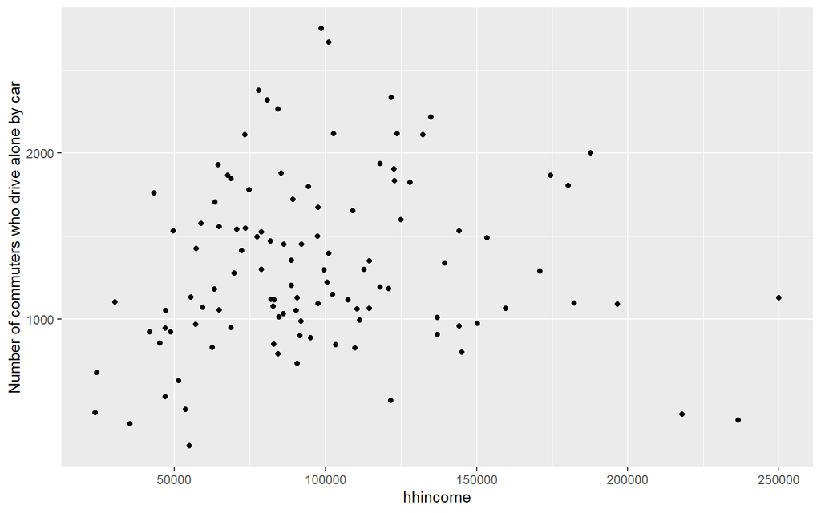

```r
ggplot(yelp_census_dropnaHH2, aes(x=hhincome, y=trans.drovealone)) +
  geom_point() +
  ylab("Number of commuters who drive alone by car")
```

Think about whether “number” of commuters who drive alone is the right variable to check against hhincome when you are seeking to explore the relationship between income and the use of cars.

The number of people who drive alone may be low if there are fewer people commuting in high income neighborhoods. So ideally you want to use PERCENT of commuters who drive alone rather than the number.

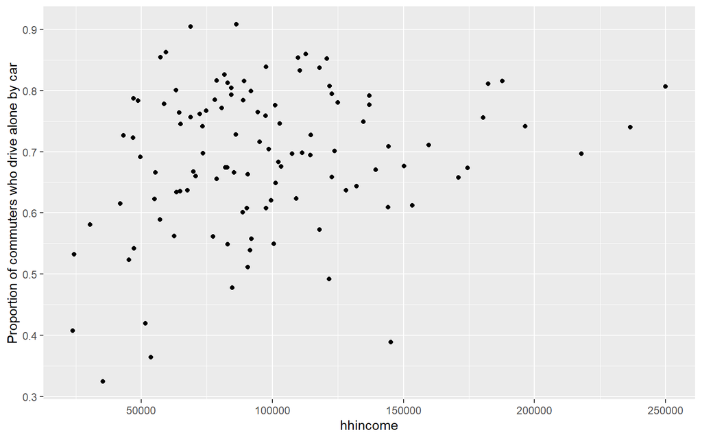

```r
yelp_census2 <- yelp_census_dropnaHH2 %>%
  mutate(prop_drovealone=trans.drovealone/trans.total)

ggplot(yelp_census2, aes(x=hhincome, y=prop_drovealone)) +
  geom_point() +
  ylab("Proportion of commuters who drive alone by car")
```

Do you notice a difference from the previous plot?

```r
yelp_census3 <- yelp_census2 %>%
  mutate(prop_white = race.white/race.tot, prop_black=race.black/race.tot)
```

Let us now check whether race has a association with drive alone

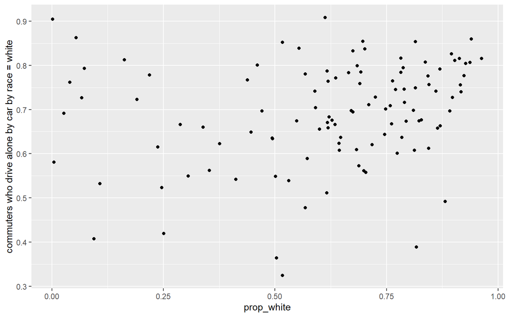

```r
ggplot(yelp_census3, aes(x=prop_white, y=prop_drovealone)) +
  geom_point() +
  ylab("commuters who drive alone by car by race = white")
```

Where are the people who drive alone?

```r
tmap_mode("view")
```

```
## tmap mode set to interactive viewing
```

```r
tm_shape(yelp_census3) +
  tm_dots(col="prop_drovealone")
```

[interactive chart not shown]

What about work from home?

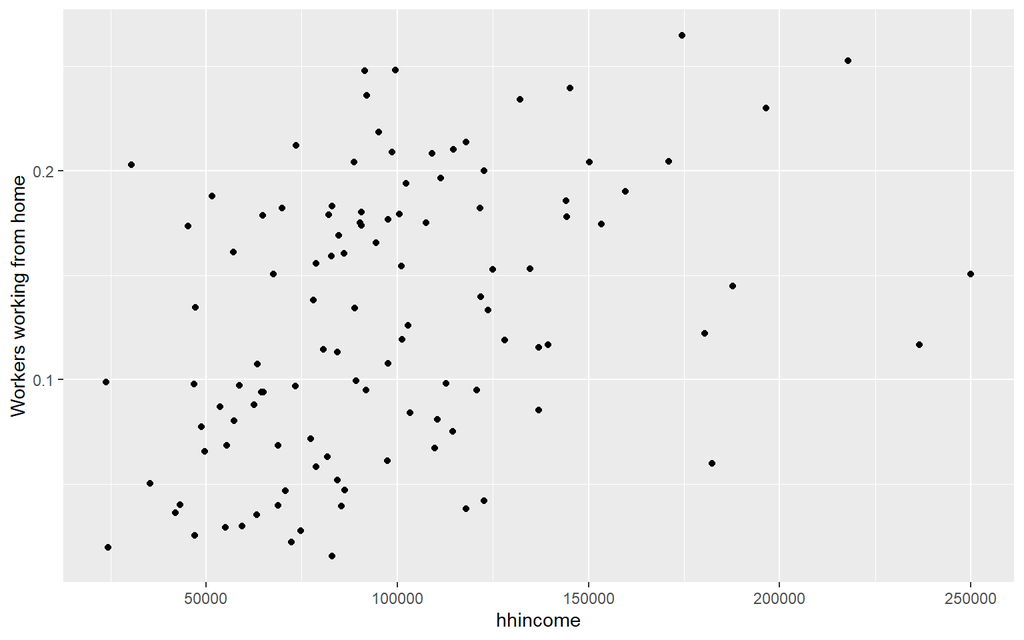

```r
yelp_census4 <- yelp_census3 %>%
  mutate(prop_wfh=trans.WfH/trans.total)

ggplot(yelp_census4, aes(x=hhincome, y=prop_wfh)) +
  geom_point() +
  ylab("Workers working from home")
```

## Adding a smoothed line

You can also fit a smoothed line to the scatterpolt

[figure not shown]

```r
scatter.smooth(yelp_census4$prop_wfh,
               yelp_census4$hhincome,
               xlab="Household Income",
               ylab="Proportion of workers working from home",
               main="Work from Home by Household Income")
```

## Simple correlations between two variables

How strong is the relationship between income and work from home? Measures of association are dependent upon the type of variables: nominal, ordinal, or ratio. Since the measures here are ratio variables, we will use the correlation coefficient.

Use > **cor(x, use=, method=)**

```r
cor(yelp_census4$prop_wfh,
    yelp_census4$hhincome,
    use="pairwise.complete.obs",
    method="pearson")
```

```
## [1] 0.3868645
```

## Bivariate regression

What about a bivariate regression to examine the relationship between work from home and income? Which variable should be the dependent?

```r
regress_wfh <- lm(yelp_census4$prop_wfh ~ yelp_census4$hhincome)
summary(regress_wfh)
```

```
##
## Call:
## lm(formula = yelp_census4$prop_wfh ~ yelp_census4$hhincome)
##
## Residuals:
##       Min        1Q    Median        3Q       Max
## -0.120000 -0.045047  0.007806  0.043848  0.118925
##
## Coefficients:
##                        Estimate Std. Error t value Pr(>|t|)
## (Intercept)           7.756e-02  1.149e-02   6.752 2.67e-10 ***
## yelp_census4$hhincome 5.616e-07  1.068e-07   5.257 4.72e-07 ***
## ---
## Signif. codes:  0 '***' 0.001 '**' 0.01 '*' 0.05 '.' 0.1 ' ' 1
##
## Residual standard error: 0.05558 on 157 degrees of freedom
## Multiple R-squared:  0.1497, Adjusted R-squared:  0.1442
## F-statistic: 27.63 on 1 and 157 DF,  p-value: 4.723e-07
```

## Plot the regression line

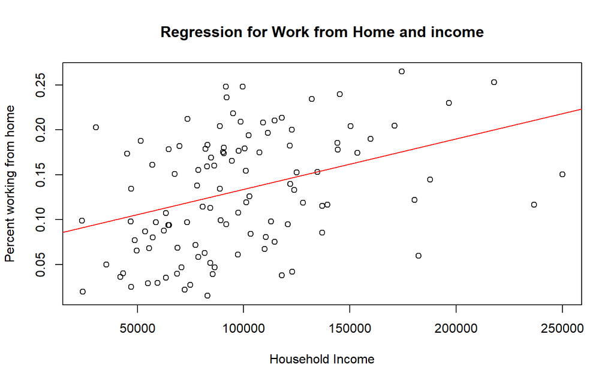

```r
plot(yelp_census4$hhincome,
     yelp_census4$prop_wfh,
     main = "Regression for Work from Home and income",
     xlab="Household Income",
     ylab="Percent working from home")

abline(lm(prop_wfh~hhincome, data=yelp_census4), col="red")
```

Can you examine some other measures of associations? Work from home vs. income? What about Yoga studios vs. income.